# Week6 - Improve bank term deposits volume at Hometown Bank

Raju Penmetcha

2017-04-25

# Overview

Analyze and understand bank customer attributes and preferred services used is necessary to grow term deposit volume at Hometown Bank. This will improve Hometown bank status, competitiveness in the marketplace and profitable.

# R Packages

The packages you will need to install for this project include **rpart**, **rpart.plot**, **VIM**, **caret**, **RandomForest**, **mlbench**, **adabag**, **ROCR**, and **doSNOW**.

# Purpose for the analysis

## Prediction Goal

We will build multiple models to predict whether a bank customer is likely to subscribe to a bank term deposit? Additionally, we will identify predictors that tell us if a customer is more likely to subscribe to a term deposit?

# Dataset

Bank provided two datasets named bank-full.csv and bank.csv, the full version is larger dataset with 40,000 rows of and smaller sample dataset contained 4,000 rows, both having with 17attributes. For better full analysis used full dataset named “bank-full.csv” with 17 attributes for this analysis and model building.

# Getting Started

Load dataset into workspace.

```r
library(readr)
getwd()
```

```
## [1] "C:/Users/Jupiter/Downloads/RU/BIA6301ADM/Homework/submission/week6/ADM_Wekk6_Project/script"
```

```r
setwd("C:/Users/Jupiter/Downloads/RU/BIA6301ADM/Homework/submission/week6/ADM_Wekk6_Project/data")

# Small bank dataset
#bank_org <- read_csv("C:/Users/Jupiter/Downloads/RU/BIA6301ADM/Homework/submission/week6/ADM_Wekk6_Project/data/bank.#csv")

# Full bank dataset
bank_org <- read_csv("C:/Users/Jupiter/Downloads/RU/BIA6301ADM/Homework/submission/week6/ADM_Wekk6_Project/data/bank-full.csv")
```

# Exploratory Data Analysis

Explore the dataset structure, variables aggregate details, and value ranges, etc.

```r
# Summary of the dataset
summary(bank_org)
```

```
##   age::number    job::category      marital::category  education::category
##  Min.   :18.00   Length:45211       Length:45211       Length:45211
##  1st Qu.:33.00   Class :character   Class :character   Class :character
##  Median :39.00   Mode  :character   Mode  :character   Mode  :character
##  Mean   :40.94
##  3rd Qu.:48.00
##  Max.   :95.00
##  default::category  balance::number  housing::category  loan::category
##  Length:45211       Min.   : -8019   Length:45211       Length:45211
##  Class :character   1st Qu.:    72   Class :character   Class :character
##  Mode  :character   Median :   448   Mode  :character   Mode  :character
##                     Mean   :  1362
##                     3rd Qu.:  1428
##                     Max.   :102127
##  contact::category   day::number    month::category    duration::number
##  Length:45211       Min.   : 1.00   Length:45211       Min.   :   0.0
##  Class :character   1st Qu.: 8.00   Class :character   1st Qu.: 103.0
##  Mode  :character   Median :16.00   Mode  :character   Median : 180.0
##                     Mean   :15.81                      Mean   : 258.2
##                     3rd Qu.:21.00                      3rd Qu.: 319.0
##                     Max.   :31.00                      Max.   :4918.0
##  campaign::number pdays::number   previous::number   poutcome::category
##  Min.   : 1.000   Min.   : -1.0   Min.   :  0.0000   Length:45211
##  1st Qu.: 1.000   1st Qu.: -1.0   1st Qu.:  0.0000   Class :character
##  Median : 2.000   Median : -1.0   Median :  0.0000   Mode  :character
##  Mean   : 2.764   Mean   : 40.2   Mean   :  0.5803
##  3rd Qu.: 3.000   3rd Qu.: -1.0   3rd Qu.:  0.0000
##  Max.   :63.000   Max.   :871.0   Max.   :275.0000
##  y::category
##  Length:45211
##  Class :character
##  Mode  :character
##
##
##
```

```r
str(bank_org)
```

```
## Classes 'tbl_df', 'tbl' and 'data.frame':    45211 obs. of  17 variables:
##  $ age::number        : int  58 44 33 47 33 35 28 42 58 43 ...
##  $ job::category      : chr  "management" "technician" "entrepreneur" "blue-collar" ...
##  $ marital::category  : chr  "married" "single" "married" "married" ...
##  $ education::category: chr  "tertiary" "secondary" "secondary" "unknown" ...
##  $ default::category  : chr  "no" "no" "no" "no" ...
##  $ balance::number    : int  2143 29 2 1506 1 231 447 2 121 593 ...
##  $ housing::category  : chr  "yes" "yes" "yes" "yes" ...
##  $ loan::category     : chr  "no" "no" "yes" "no" ...
##  $ contact::category  : chr  "unknown" "unknown" "unknown" "unknown" ...
##  $ day::number        : int  5 5 5 5 5 5 5 5 5 5 ...
##  $ month::category    : chr  "may" "may" "may" "may" ...
##  $ duration::number   : int  261 151 76 92 198 139 217 380 50 55 ...
##  $ campaign::number   : int  1 1 1 1 1 1 1 1 1 1 ...
##  $ pdays::number      : int  -1 -1 -1 -1 -1 -1 -1 -1 -1 -1 ...
##  $ previous::number   : int  0 0 0 0 0 0 0 0 0 0 ...
##  $ poutcome::category : chr  "unknown" "unknown" "unknown" "unknown" ...
##  $ y::category        : chr  "no" "no" "no" "no" ...
##  - attr(*, "spec")=List of 2
##   ..$ cols   :List of 17
##   .. ..$ age::number        : list()
##   .. .. ..- attr(*, "class")= chr  "collector_integer" "collector"
##   .. ..$ job::category      : list()
##   .. .. ..- attr(*, "class")= chr  "collector_character" "collector"
##   .. ..$ marital::category  : list()
##   .. .. ..- attr(*, "class")= chr  "collector_character" "collector"
##   .. ..$ education::category: list()
##   .. .. ..- attr(*, "class")= chr  "collector_character" "collector"
##   .. ..$ default::category  : list()
##   .. .. ..- attr(*, "class")= chr  "collector_character" "collector"
##   .. ..$ balance::number    : list()
##   .. .. ..- attr(*, "class")= chr  "collector_integer" "collector"
##   .. ..$ housing::category  : list()
##   .. .. ..- attr(*, "class")= chr  "collector_character" "collector"
##   .. ..$ loan::category     : list()
##   .. .. ..- attr(*, "class")= chr  "collector_character" "collector"
##   .. ..$ contact::category  : list()
##   .. .. ..- attr(*, "class")= chr  "collector_character" "collector"
##   .. ..$ day::number        : list()
##   .. .. ..- attr(*, "class")= chr  "collector_integer" "collector"
##   .. ..$ month::category    : list()
##   .. .. ..- attr(*, "class")= chr  "collector_character" "collector"
##   .. ..$ duration::number   : list()
##   .. .. ..- attr(*, "class")= chr  "collector_integer" "collector"
##   .. ..$ campaign::number   : list()
##   .. .. ..- attr(*, "class")= chr  "collector_integer" "collector"
##   .. ..$ pdays::number      : list()
##   .. .. ..- attr(*, "class")= chr  "collector_integer" "collector"
##   .. ..$ previous::number   : list()
##   .. .. ..- attr(*, "class")= chr  "collector_integer" "collector"
##   .. ..$ poutcome::category : list()
##   .. .. ..- attr(*, "class")= chr  "collector_character" "collector"
##   .. ..$ y::category        : list()
##   .. .. ..- attr(*, "class")= chr  "collector_character" "collector"
##   ..$ default: list()
##   .. ..- attr(*, "class")= chr  "collector_guess" "collector"
##   ..- attr(*, "class")= chr "col_spec"
```

# Visulaize missing data

Visulaize and understand variable data ranges, any missing data, and etc.

```r
library(VIM)
```

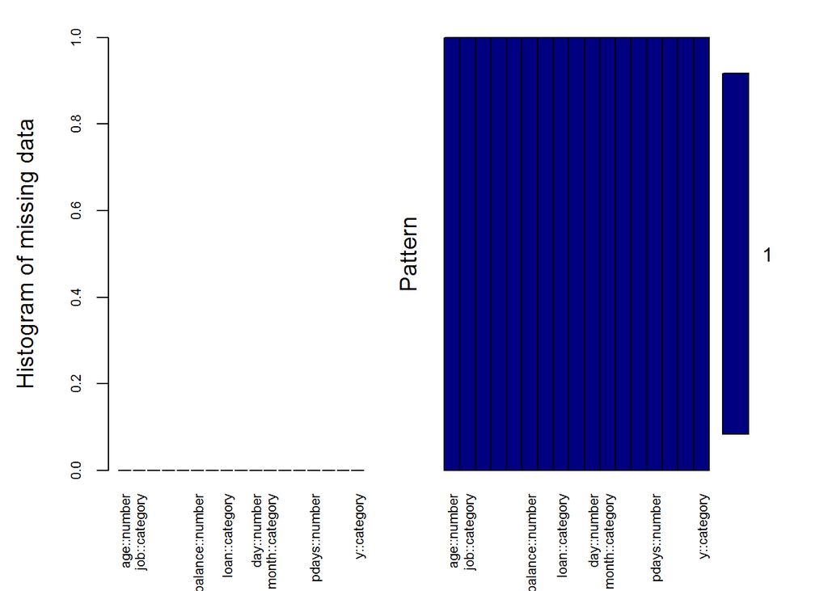

```
##
##  Variables sorted by number of missings:
##             Variable Count
##          age::number     0
##        job::category     0
##    marital::category     0
##  education::category     0
##    default::category     0
##      balance::number     0
##    housing::category     0
##       loan::category     0
##    contact::category     0
##          day::number     0
##      month::category     0
##     duration::number     0
##     campaign::number     0
##        pdays::number     0
##     previous::number     0
##   poutcome::category     0
##          y::category     0
```

```r
aggr_plot <- aggr(bank_org, col=c('navyblue','red'), numbers=TRUE, sortVars=TRUE, labels=names(bank_org), cex.axis=.7, gap=3, ylab=c("Histogram of missing data","Pattern"))
```

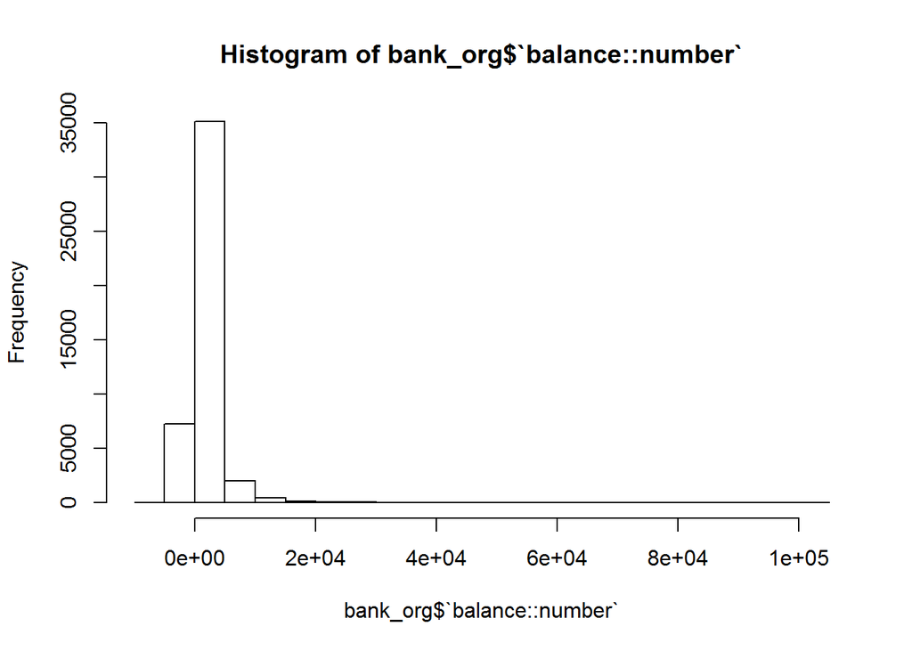

```r
hist(bank_org$`balance::number`)
```

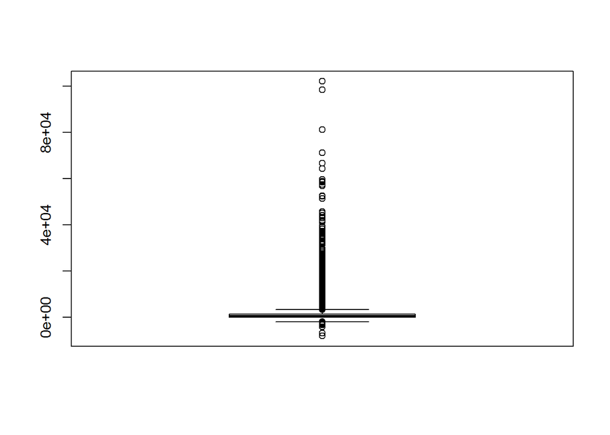

```r
boxplot(bank_org$`balance::number`)
```

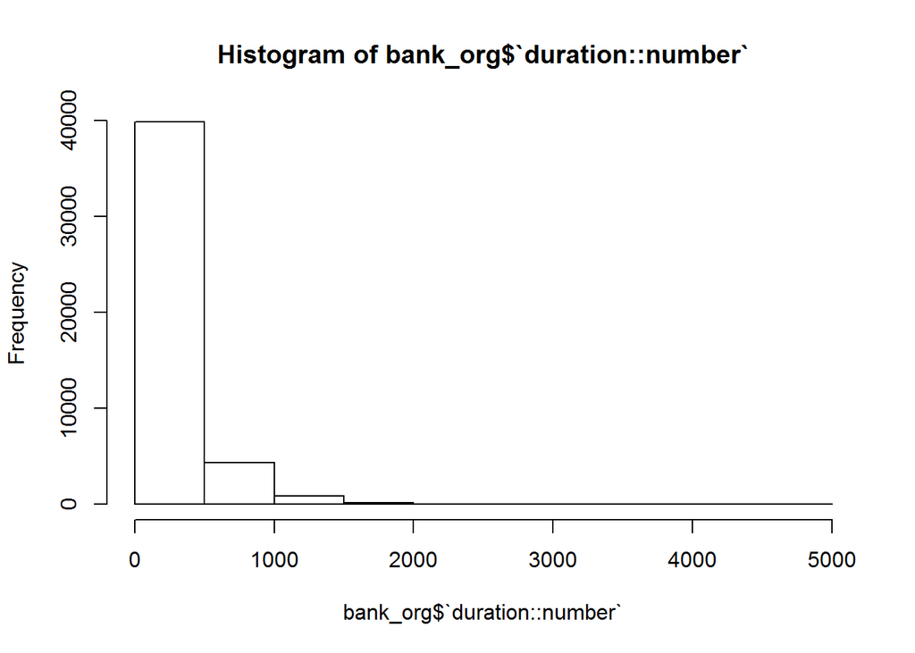

```r
hist(bank_org$`duration::number`)
```

**No missing values were found in the dataset variables for the analysis**

# Rearrange and restructure data for proper analysis and model build.

- Rearrange the target term deposit (output) yes or no variable as a first column.
- Change categorical variables into factor variables.
- Update variable names to more meaningful and easier to identify.

```r
bank <-bank_org[,c(17,1:16)] #Rearranging the columns so that our target variable is first
#names(bank) <- make.names(names(bank))
#bank_names <- strsplit(names(bank),"::")
# update the variable names
names(bank) <- make.names(c("termdeposit", "age", "job", "marital", "education",
                            "default", "balance", "housing", "loan",
                            "contact", "day", "month", "duration", "campaign",
                            "pdays", "previous", "poutcome"))

names(bank)
```

```
##  [1] "termdeposit" "age"         "job"         "marital"     "education"
##  [6] "default"     "balance"     "housing"     "loan"        "contact"
## [11] "day"         "month"       "duration"    "campaign"    "pdays"
## [16] "previous"    "poutcome"
```

```r
dim(bank)
```

```
## [1] 45211    17
```

```r
# Change catagorical variables to facotrs
bank$termdeposit <- as.factor(bank$termdeposit)
bank$termdeposit <- relevel(bank$termdeposit,ref = "yes")
bank$job <- as.factor(bank$job)
bank$marital <- as.factor(bank$marital)
bank$education <- as.factor(bank$education)
bank$default <- as.factor(bank$default)
bank$housing <- as.factor(bank$housing)
bank$loan <- as.factor(bank$loan)
bank$contact <- as.factor(bank$contact)
bank$month <- as.factor(bank$month)
bank$poutcome <- as.factor(bank$poutcome)

summary(bank)
```

```
##  termdeposit      age                 job           marital
##  yes: 5289   Min.   :18.00   blue-collar:9732   divorced: 5207
##  no :39922   1st Qu.:33.00   management :9458   married :27214
##              Median :39.00   technician :7597   single  :12790
##              Mean   :40.94   admin.     :5171
##              3rd Qu.:48.00   services   :4154
##              Max.   :95.00   retired    :2264
##                              (Other)    :6835
##      education     default        balance       housing      loan
##  primary  : 6851   no :44396   Min.   : -8019   no :20081   no :37967
##  secondary:23202   yes:  815   1st Qu.:    72   yes:25130   yes: 7244
##  tertiary :13301               Median :   448
##  unknown  : 1857               Mean   :  1362
##                                3rd Qu.:  1428
##                                Max.   :102127
##
##       contact           day            month          duration
##  cellular :29285   Min.   : 1.00   may    :13766   Min.   :   0.0
##  telephone: 2906   1st Qu.: 8.00   jul    : 6895   1st Qu.: 103.0
##  unknown  :13020   Median :16.00   aug    : 6247   Median : 180.0
##                    Mean   :15.81   jun    : 5341   Mean   : 258.2
##                    3rd Qu.:21.00   nov    : 3970   3rd Qu.: 319.0
##                    Max.   :31.00   apr    : 2932   Max.   :4918.0
##                                    (Other): 6060
##     campaign          pdays          previous           poutcome
##  Min.   : 1.000   Min.   : -1.0   Min.   :  0.0000   failure: 4901
##  1st Qu.: 1.000   1st Qu.: -1.0   1st Qu.:  0.0000   other  : 1840
##  Median : 2.000   Median : -1.0   Median :  0.0000   success: 1511
##  Mean   : 2.764   Mean   : 40.2   Mean   :  0.5803   unknown:36959
##  3rd Qu.: 3.000   3rd Qu.: -1.0   3rd Qu.:  0.0000
##  Max.   :63.000   Max.   :871.0   Max.   :275.0000
##
```

```r
#job1 <- factor(bank$job)
#job1_dummy <- model.matrix(~job1-1)
#summary(job1_dummy)
#bank_numeric_vars <- bank[,c(2,7,11,13:16)]
```

**Normalize numeric variables and combine with rest of the categorical dummy variables**

```r
bank_num <-bank[,c(2,7,15)]
normalize<- function(x){return((x-min(x))/(max(x)-min(x)))}
bank_n<-as.data.frame(lapply(bank_num, normalize))
summary(bank_n)
```

```
##       age            balance            pdays
##  Min.   :0.0000   Min.   :0.00000   Min.   :0.00000
##  1st Qu.:0.1948   1st Qu.:0.07346   1st Qu.:0.00000
##  Median :0.2727   Median :0.07687   Median :0.00000
##  Mean   :0.2979   Mean   :0.08517   Mean   :0.04725
##  3rd Qu.:0.3896   3rd Qu.:0.08577   3rd Qu.:0.00000
##  Max.   :1.0000   Max.   :1.00000   Max.   :1.00000
```

```r
bank <- cbind(bank[,c(-2,-7,-15)], bank_n)

summary(bank)
```

```
##  termdeposit          job           marital          education
##  yes: 5289   blue-collar:9732   divorced: 5207   primary  : 6851
##  no :39922   management :9458   married :27214   secondary:23202
##              technician :7597   single  :12790   tertiary :13301
##              admin.     :5171                    unknown  : 1857
##              services   :4154
##              retired    :2264
##              (Other)    :6835
##  default     housing      loan            contact           day
##  no :44396   no :20081   no :37967   cellular :29285   Min.   : 1.00
##  yes:  815   yes:25130   yes: 7244   telephone: 2906   1st Qu.: 8.00
##                                      unknown  :13020   Median :16.00
##                                                        Mean   :15.81
##                                                        3rd Qu.:21.00
##                                                        Max.   :31.00
##
##      month          duration         campaign         previous
##  may    :13766   Min.   :   0.0   Min.   : 1.000   Min.   :  0.0000
##  jul    : 6895   1st Qu.: 103.0   1st Qu.: 1.000   1st Qu.:  0.0000
##  aug    : 6247   Median : 180.0   Median : 2.000   Median :  0.0000
##  jun    : 5341   Mean   : 258.2   Mean   : 2.764   Mean   :  0.5803
##  nov    : 3970   3rd Qu.: 319.0   3rd Qu.: 3.000   3rd Qu.:  0.0000
##  apr    : 2932   Max.   :4918.0   Max.   :63.000   Max.   :275.0000
##  (Other): 6060
##     poutcome          age            balance            pdays
##  failure: 4901   Min.   :0.0000   Min.   :0.00000   Min.   :0.00000
##  other  : 1840   1st Qu.:0.1948   1st Qu.:0.07346   1st Qu.:0.00000
##  success: 1511   Median :0.2727   Median :0.07687   Median :0.00000
##  unknown:36959   Mean   :0.2979   Mean   :0.08517   Mean   :0.04725
##                  3rd Qu.:0.3896   3rd Qu.:0.08577   3rd Qu.:0.00000
##                  Max.   :1.0000   Max.   :1.00000   Max.   :1.00000
##
```

# Create training and validation data set for analysis

Let’s do a training set of 80% and validation set of 20%. We will build a decision tree model on 80% of the data set and then test the model’s performance on the other 20% of the data set.

```r
set.seed(123) #set a seed to do draws from a random uniform distribution.
# for bank's small dataset split
#bank_rand <- bank[order(runif(4521)), ]
#bank_train <- bank_rand[1:4000, ] #Training data set; 4000 observations
#bank_validate  <-bank_rand[4001:4521, ]

# for bank's full dataset split
bank_rand <- bank[order(runif(45211)), ]
bank_train <- bank_rand[1:36000, ] #Training data set; 36000 observations
bank_validate  <-bank_rand[36001:45211, ]
```

```r
dim(bank_train) #checking the split
```

```
## [1] 36000    17
```

```r
dim(bank_validate) #checking the split
```

```
## [1] 9211   17
```

```r
prop.table(table(bank_train$termdeposit)) #checking to see the class proportions between the training and test sets.
```

```
##
##       yes        no
## 0.1171944 0.8828056
```

```r
prop.table(table(bank_validate$termdeposit))
```

```
##
##       yes        no
## 0.1161655 0.8838345
```

Checking the proportions of term desposit variable in the trainining and validation sets. They are roughly the same. 11.71% in training set have term deposit; 11.613% in validation set have term deposit.

# Analysis - Using superwised learning method of Decision Trees

## Decision Trees is a more sophisticated classification Model

Decision trees follow recursive partitioning (top down greedy divide and conquer approach)

1. Choose the attribute that is most predictive of the target variable
2. Observations in the training data set are divided into groups of distinct values. This form the first set of branches.
3. Continue to divide and conquer the nodes, choosing the feature with the most prediction power each time until one of three conditions occur:
- all observations for a given node belong to the same class
- no more remaining attributes for further partitioning
- no observations are left

## To perform multiple approaches, following different models are used for the analysis and to predict the customer likely subscribing to term deposit outcome.

# Option 1: Using the rpart to Build a Decision Tree model

```r
library(rpart)
library(rpart.plot)

set.seed(123)
bank_rpart <- rpart(bank_train$termdeposit~., method="class", parms = list(split="gini"), data=bank_train)
#bank_rpart <- rpart(bank_train$termdeposit~., method="class", parms = list(split="information"), data=bank_train)

summary(bank_rpart)
```

```
## Call:
## rpart(formula = bank_train$termdeposit ~ ., data = bank_train,
##     method = "class", parms = list(split = "gini"))
##   n= 36000
##
##           CP nsplit rel error    xerror       xstd
## 1 0.03760765      0 1.0000000 1.0000000 0.01446531
## 2 0.02465039      3 0.8871771 0.8881251 0.01373302
## 3 0.02228016      4 0.8625267 0.8646599 0.01357117
## 4 0.01000000      5 0.8402465 0.8435648 0.01342302
##
## Variable importance
## duration poutcome
##       62       37
##
## Node number 1: 36000 observations,    complexity param=0.03760765
##   predicted class=no   expected loss=0.1171944  P(node) =1
##     class counts:  4219 31781
##    probabilities: 0.117 0.883
##   left son=2 (4745 obs) right son=3 (31255 obs)
##   Primary splits:
##       duration < 472.5      to the right, improve=941.9424, (0 missing)
##       poutcome splits as  RRLR, improve=723.3326, (0 missing)
##       month    splits as  RRLRRRRLRRLL, improve=416.0150, (0 missing)
##       pdays    < 0.0108945  to the right, improve=219.7189, (0 missing)
##       previous < 0.5        to the right, improve=216.5865, (0 missing)
##
## Node number 2: 4745 observations,    complexity param=0.03760765
##   predicted class=no   expected loss=0.4107482  P(node) =0.1318056
##     class counts:  1949  2796
##    probabilities: 0.411 0.589
##   left son=4 (1544 obs) right son=5 (3201 obs)
##   Primary splits:
##       duration < 800.5      to the right, improve=127.61900, (0 missing)
##       poutcome splits as  RRLR, improve= 73.22054, (0 missing)
##       contact  splits as  LLR, improve= 67.96610, (0 missing)
##       month    splits as  RLLRRRRLRRLL, improve= 42.15556, (0 missing)
##       housing  splits as  LR, improve= 36.19915, (0 missing)
##   Surrogate splits:
##       previous < 26.5       to the right, agree=0.675, adj=0.001, (0 split)
```

[output cut: 58 more lines]

```
##
## Node number 11: 3043 observations
##   predicted class=no   expected loss=0.3059481  P(node) =0.08452778
##     class counts:   931  2112
##    probabilities: 0.306 0.694
##
## Node number 12: 802 observations
##   predicted class=yes  expected loss=0.2880299  P(node) =0.02227778
##     class counts:   571   231
##    probabilities: 0.712 0.288
##
## Node number 13: 188 observations
##   predicted class=no   expected loss=0.2234043  P(node) =0.005222222
##     class counts:    42   146
##    probabilities: 0.223 0.777
```

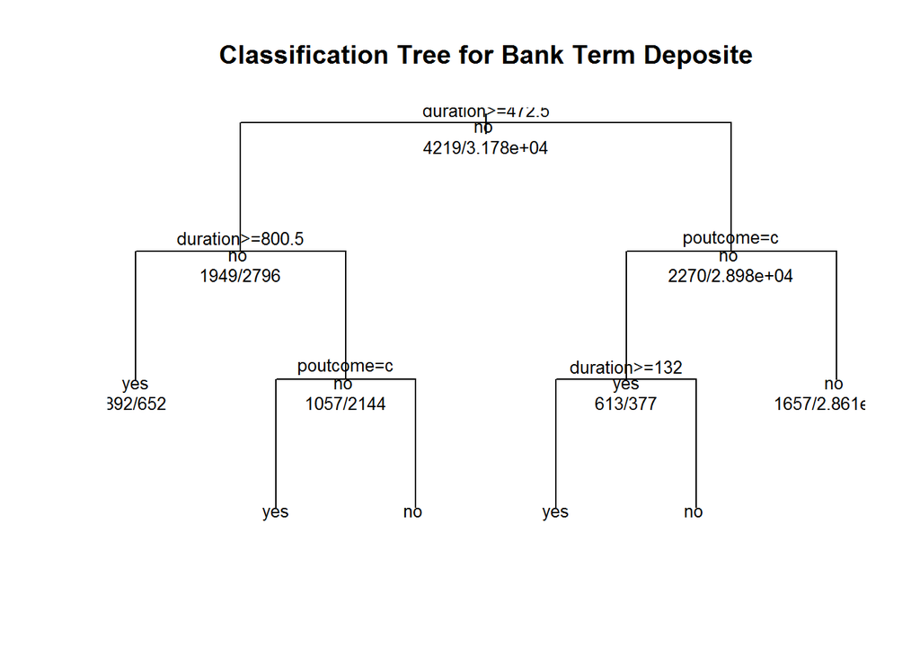

```r
plot(bank_rpart, uniform=TRUE, main="Classification Tree for Bank Term Deposite")
text(bank_rpart, use.n=TRUE, all=TRUE, cex=0.8)
```

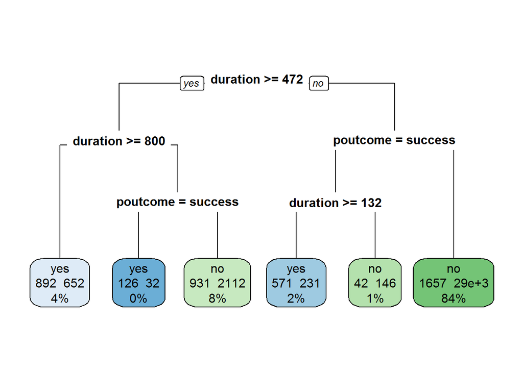

```r
# plot results into a graph
library(rpart.plot)
rpart.plot(bank_rpart, type=0, extra=101)
```

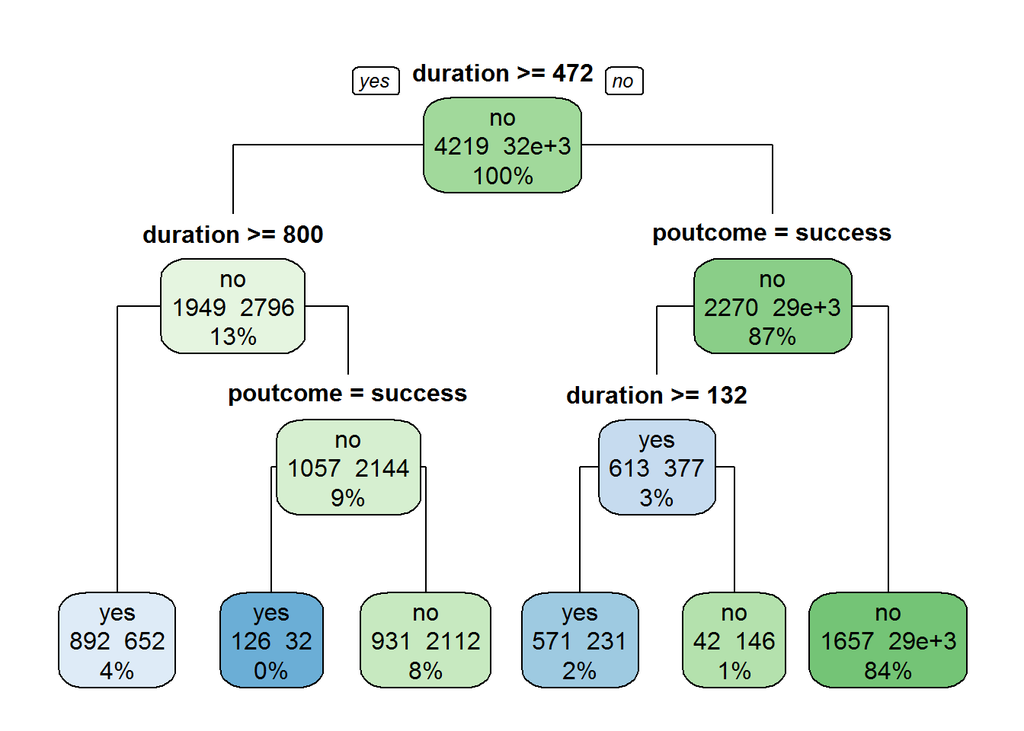

```r
rpart.plot(bank_rpart, type=1, extra=101)
```

## Run rpart model validation

```r
library(caret)
actual <- bank_validate$termdeposit
predicted_rpart <- predict(bank_rpart, bank_validate, type="class")
results.matrix_rpart <- confusionMatrix(predicted_rpart, actual, positive="yes")
print(results.matrix_rpart)
```

```
## Confusion Matrix and Statistics
##
##           Reference
## Prediction  yes   no
##        yes  375  243
##        no   695 7898
##
##                Accuracy : 0.8982
##                  95% CI : (0.8918, 0.9043)
##     No Information Rate : 0.8838
##     P-Value [Acc > NIR] : 6.736e-06
##
##                   Kappa : 0.3927
##  Mcnemar's Test P-Value : < 2.2e-16
##
##             Sensitivity : 0.35047
##             Specificity : 0.97015
##          Pos Pred Value : 0.60680
##          Neg Pred Value : 0.91912
##              Prevalence : 0.11617
##          Detection Rate : 0.04071
##    Detection Prevalence : 0.06709
##       Balanced Accuracy : 0.66031
##
##        'Positive' Class : yes
##
```

*Option 1: Accuracy rate is 90%, but the sensitivity (how well does the decision tree classified likely term deposit subscriber correctly) is only 35%. Furthermore, the specificity (how well does the decision tree classified non-subscriber of term deposit correctly) is 97%. Our decision tree model does a better job classifying the non-subscriber of term deposit better than the subscriber of the term deposit. KAPA is 0.39*

# Option 2: Using the C5.0 to Build a Decision Tree model

## Create training and test sets for the C5.0 model

```r
set.seed(123) #set a seed to do draws from a random uniform distribution.
bank_c50_rand <- bank[order(runif(45211)), ]

# use same rand data from above to be consistance
bank_c50_train <- bank_rand[1:36000,c(-1)] #Training data set; observations 80% of sample
bank_c50_test  <- bank_rand[36001:45211,c(-1)] # Test data seet; observations 20% of sample

bank_c50_train_labels <- bank_rand[1:36000,c(1) ]
bank_c50_test_lables  <- bank_rand[36001:45211,c(1) ]
```

## Use C50 pakage for decision tree

```r
library(C50)
library(partykit)
set.seed(123)

bank_pred_c50 <- C50::C5.0(bank_c50_train, bank_c50_train_labels, trials=1)

summary(bank_pred_c50)
```

```
##
## Call:
## C5.0.default(x = bank_c50_train, y = bank_c50_train_labels, trials = 1)
##
##
## C5.0 [Release 2.07 GPL Edition]      Tue Apr 25 00:32:34 2017
## -------------------------------
##
## Class specified by attribute `outcome'
##
## Read 36000 cases (17 attributes) from undefined.data
##
## Decision tree:
##
## poutcome = success:
## :...duration <= 162:
## :   :...duration <= 80: no (54/4)
## :   :   duration > 80:
## :   :   :...month in {apr,jul,may,nov,oct}: no (90/26)
## :   :       month = dec:
## :   :       :...duration <= 138: no (4)
## :   :       :   duration > 138: yes (3)
## :   :       month = feb:
## :   :       :...day <= 5: no (10/2)
## :   :       :   day > 5: yes (15/5)
## :   :       month = jan:
## :   :       :...marital in {divorced,single}: no (5)
## :   :       :   marital = married: yes (4/1)
## :   :       month = jun:
## :   :       :...previous <= 3: no (20/5)
## :   :       :   previous > 3: yes (3)
## :   :       month = mar:
## :   :       :...education in {primary,unknown}: no (3)
## :   :       :   education in {secondary,tertiary}: yes (7/1)
## :   :       month = sep:
## :   :       :...campaign <= 2: yes (13/1)
## :   :       :   campaign > 2: no (3)
## :   :       month = aug:
## :   :       :...day <= 8:
## :   :           :...contact in {cellular,unknown}: yes (10/2)
```

[output cut: 772 more lines]

```
##   89.47% age
##   83.68% day
##   50.88% contact
##   12.79% housing
##    5.23% job
##    5.14% education
##    2.94% marital
##    1.87% campaign
##    1.61% balance
##    1.23% previous
##    1.01% loan
##    0.53% default
##
##
## Time: 0.4 secs
```

```r
#bank_pred_c50_party <- as.party(C50::C5.0(bank_c50_train, bank_c50_train_labels, trials=1))
#plot(bank_pred_c50_party[1])
```

## Run test data using the c5.0 model and validate

```r
library(caret)
actual_c50 <- bank_c50_test_lables
predicted_c50 <- predict(bank_pred_c50, bank_c50_test, type="class")
#summary(predicted_c50)
results.matrix_c50 <- confusionMatrix(predicted_c50, actual_c50, positive="yes")
print(results.matrix_c50)
```

```
## Confusion Matrix and Statistics
##
##           Reference
## Prediction  yes   no
##        yes  480  316
##        no   590 7825
##
##                Accuracy : 0.9016
##                  95% CI : (0.8954, 0.9076)
##     No Information Rate : 0.8838
##     P-Value [Acc > NIR] : 2.685e-08
##
##                   Kappa : 0.4611
##  Mcnemar's Test P-Value : < 2.2e-16
##
##             Sensitivity : 0.44860
##             Specificity : 0.96118
##          Pos Pred Value : 0.60302
##          Neg Pred Value : 0.92989
##              Prevalence : 0.11617
##          Detection Rate : 0.05211
##    Detection Prevalence : 0.08642
##       Balanced Accuracy : 0.70489
##
##        'Positive' Class : yes
##
```

- Option 2: Accuracy rate is 90%, but the sensitivity (how well does the decision tree classified likely term deposit subscriber correctly) is improved to 45%. Furthermore, the specificity (how well does the decision tree classified non-subscriber of term deposit correctly) is 96%. Our C5.0 decision tree model does a better job classifying the non-subscriber of term deposit than the likely subscriber of the term deposit. KAPA is 0.46.

# Other options: Improving Model Performance: Ensemble Models Approach

1. Bagging (bootstrap aggregation)
2. Random forests (many trees = a forest)

## Option 3: Bagging

Bagging is a 4 step process:

1. Generate B bootstrap samples from the training set.
2. Construct decision trees for all B bootstrap samples.
3. For each given test observation, we record the class predicted by each of the B trees.
4. The overall prediction is the most commonly occuring class among the B predictions. Majority voting wins.

Bagging averages many trees so it reduces the variance of the instability of generating just one tree. Bagging leads to improved prediction. The tradeoff is you lose interpretability and the ability to see simple structure in a tree.

```r
library(randomForest)
set.seed(123)

#Set mtry to equal all predictors. This means all predictors should be considered at each split. This is what makes it "bagging." The default number of trees is 500.
names(bank_train) <- make.names(names(bank_train))

bank.bag <- randomForest(termdeposit~., mtry=16, data=bank_train, na.action=na.omit, importance=TRUE)
```

### Out of Bag (OOB) Error

```r
print(bank.bag) #note the "out of bag" (OOB) error rate.
```

```
##
## Call:
##  randomForest(formula = termdeposit ~ ., data = bank_train, mtry = 16,      importance = TRUE, na.action = na.omit)
##                Type of random forest: classification
##                      Number of trees: 500
## No. of variables tried at each split: 16
##
##         OOB estimate of  error rate: 9.23%
## Confusion matrix:
##      yes    no class.error
## yes 2067  2152  0.51007348
## no  1172 30609  0.03687738
```

### What are the important predictors in our bagging model?

Look at the mean decrease in accuracy of predictions in the OOB samples when a given variable is excluded.

```r
importance(bank.bag, type=1)
```

```
##           MeanDecreaseAccuracy
## job                  26.505441
## marital              15.173999
## education            23.497304
## default               1.425542
## housing              67.940671
## loan                 11.878884
## contact              80.749574
## day                 106.123586
## month               153.895496
## duration            298.697748
## campaign             28.851152
## previous             26.642823
## poutcome             73.322500
## age                  64.841073
## balance              13.218153
## pdays                67.367026
```

Look at the mean decrease in node impurity resulting from splits over that variable.

```r
importance(bank.bag, type=2)
```

```
##           MeanDecreaseGini
## job             498.246341
## marital         114.619543
## education       133.190212
## default           9.283417
## housing          89.092899
## loan             37.160883
## contact         136.536613
## day             647.717636
## month           744.460630
## duration       2166.357897
## campaign        255.600436
## previous        118.522307
## poutcome        715.663415
## age             679.842037
## balance         793.926826
## pdays           300.300573
```

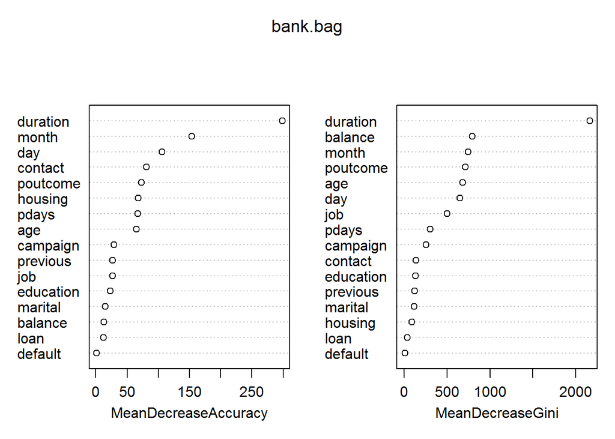

```r
varImpPlot(bank.bag)
```

```r
actual <- bank_validate$termdeposit
bank_predicted_bag <- predict(bank.bag, newdata=bank_validate, type="class")
bank_results.matrix.bag <- confusionMatrix(bank_predicted_bag, actual, positive="yes")
print(bank_results.matrix.bag)
```

```
## Confusion Matrix and Statistics
##
##           Reference
## Prediction  yes   no
##        yes  490  293
##        no   580 7848
##
##                Accuracy : 0.9052
##                  95% CI : (0.8991, 0.9111)
##     No Information Rate : 0.8838
##     P-Value [Acc > NIR] : 2.507e-11
##
##                   Kappa : 0.4776
##  Mcnemar's Test P-Value : < 2.2e-16
##
##             Sensitivity : 0.45794
##             Specificity : 0.96401
##          Pos Pred Value : 0.62580
##          Neg Pred Value : 0.93118
##              Prevalence : 0.11617
##          Detection Rate : 0.05320
##    Detection Prevalence : 0.08501
##       Balanced Accuracy : 0.71098
##
##        'Positive' Class : yes
##
```

- Option 3: Accuracy rate is 90%, but the sensitivity (how well does the decision tree classified likely term deposit subscriber correctly) is 45%. The specificity (how well does the decision tree classified non-subscriber of term deposit correctly) is 96%. Bagging decision tree model also does a better job classifying the non-subscriber of term deposit than the likely subscriber of the term deposit. KAPA is 0.47.

## Option 4: Random Forest

Random forests generate a large number of classification trees, and then does a majority vote to generate prediction.

```r
bank.RForest <- randomForest(termdeposit ~.,data=bank_train, mtry=16, ntree=500,na.action = na.omit, importance=TRUE)

print(bank.RForest)
```

```
##
## Call:
##  randomForest(formula = termdeposit ~ ., data = bank_train, mtry = 16,      ntree = 500, importance = TRUE, na.action = na.omit)
##                Type of random forest: classification
##                      Number of trees: 500
## No. of variables tried at each split: 16
##
##         OOB estimate of  error rate: 9.29%
## Confusion matrix:
##      yes    no class.error
## yes 2066  2153  0.51031050
## no  1190 30591  0.03744376
```

```r
importance(bank.RForest)
```

```
##                  yes         no MeanDecreaseAccuracy MeanDecreaseGini
## job        11.987274  22.989516            26.871733        497.40706
## marital    13.568597  10.701656            17.055481        114.68278
## education   5.886238  20.999020            21.734306        136.93909
## default     1.001014   1.060557             1.427675         10.46912
## housing    29.119850  59.866093            69.994127         91.86711
## loan       10.528432   5.752172            12.145935         37.06031
## contact     3.075466  79.967910            81.461355        136.99729
## day        13.673824  99.876720           100.808594        649.64134
## month      50.395610 146.885452           155.703315        742.36564
## duration  326.095638 162.817611           294.057837       2165.15787
## campaign   11.225693  27.477708            29.063524        254.58592
## previous    5.380935  26.234789            26.516671        120.56343
## poutcome  112.327049  42.210020            69.429481        715.76987
## age        19.538329  60.790882            65.561674        673.96732
## balance    10.301432   9.124929            13.506429        795.73473
## pdays      32.679529  49.193816            63.547898        299.61458
```

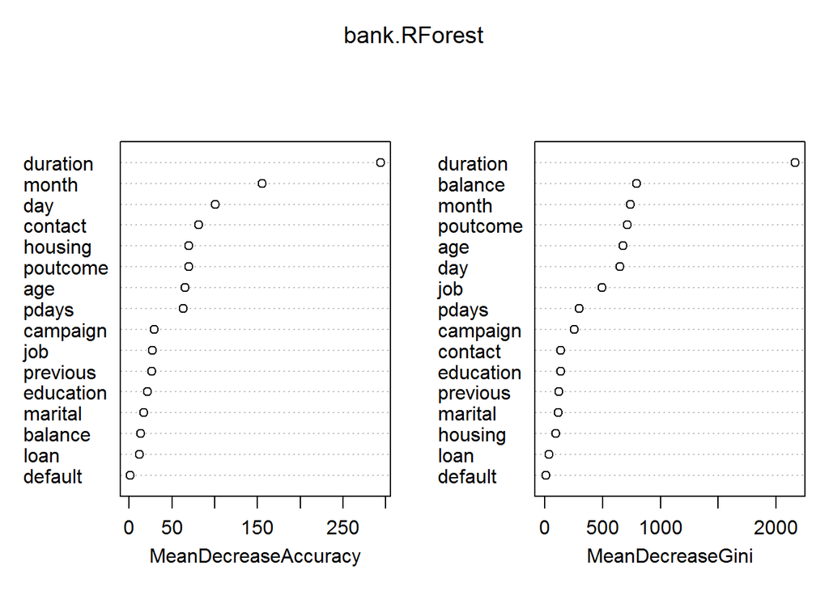

```r
varImpPlot(bank.RForest)
```

## Random Forest

```r
actual <- bank_validate$termdeposit
bank_predicted_rf <- predict(bank.RForest, newdata=bank_validate, type="class")
bank_results.matrix.rf <- confusionMatrix(bank_predicted_rf, actual, positive="yes")
print(bank_results.matrix.rf)
```

```
## Confusion Matrix and Statistics
##
##           Reference
## Prediction  yes   no
##        yes  493  285
##        no   577 7856
##
##                Accuracy : 0.9064
##                  95% CI : (0.9003, 0.9123)
##     No Information Rate : 0.8838
##     P-Value [Acc > NIR] : 1.819e-12
##
##                   Kappa : 0.483
##  Mcnemar's Test P-Value : < 2.2e-16
##
##             Sensitivity : 0.46075
##             Specificity : 0.96499
##          Pos Pred Value : 0.63368
##          Neg Pred Value : 0.93158
##              Prevalence : 0.11617
##          Detection Rate : 0.05352
##    Detection Prevalence : 0.08446
##       Balanced Accuracy : 0.71287
##
##        'Positive' Class : yes
##
```

- Option 4: Accuracy rate is 90%, but the sensitivity (how well does the decision tree classified likely term deposit subscriber correctly) is improved to 46%. The specificity (how well does the decision tree classified non-subscriber of term deposit correctly) is 96%. Random Forest decision tree model also does a better job classifying the non-subscriber of term deposit than the likely subscriber of the term deposit. KAPA is 0.48.

**KAPA Reference** Kappa “adjusts accuracy by accounting for the possibility of a correct prediction by **chance alone.** Kappa values range to a maximum number of 1, which indicates perfect agreement between the model’s predictions and the true values–a rare occurrence. Values less than one indicate imperfect agreement” (Lantz 2013, p. 303)

Landis and Koch (1977): 0-20 => slight, 0.21-.40 => fair, 0.41-0.6 => moderate, 0.61-0.8 => substantial, 0.81 -1 => almost perfect

Fleiss (1981): 0-.40 => poor; 0.41-0.75 => fair to good; 0.75 – 1 => excellent.

# Following is the summary of model analysis and performance information

```
|---------------------------------------------------------------|
|               |  rpart  |  C5.0  |  Bagging  |  RandomForest  |
|---------------|---------|--------|-----------|----------------|
| Accuracy      |  90%    |  90%   |   90%     |     90%        |
| Sensitivity   |  35%    |  45%   |   45%     |     46%        |
| Specificity   |  97%    |  96%   |   96%     |     96%        |
| KAPA          |  0.39   |  0.46  |   0.47    |     0.48       |
|---------------------------------------------------------------|
```

- Based the performance of Accuracy, Sensitivity, Specificity, and KAPA measurements, the Random Forest model to be marginally better to other models and it is taken into consideration for the recommendation. Speciic details for recommendation are considered from C5.0 model details.

# Significant Predictors

*Based on the analysis following customer attributes and facotrs found to be significant predictors to asses a customer likley to subscribe for term deposit.*

- Duration - last contact duration with customer in seconds.
- Poutcome - outcome of the privious marketing campaign.
- Last contact month of year (jan to dec).
- Last contact day of the month (1-31).
- Average yearly balance in Euros.
- Customer Age.
- Customer has a housing loan.

# Final Recommendations

**To increase term deposit subscription volume at Hometown Bank and improve its status in marketplace and profitablity. Following customer outreach and campaign action items are recommended to Hometown Bank managment.**

- Create a marketing campaign with incentives for customers to open new term deposit with the Hometown Bank. Reach out to the customers when the visit the branch and provide complete details and benefits of term deposit in personal financial planning. Analysis has showed that when customer is in contact with bank for service or help for more than 5 minutes the customer is likely to subscribe to term deposits if it is presented.
- Initiate customer outreach effort during the months of March, September, October, and December. These months identified to be more effective month in a year to reach out to the customers for term deposit subscriptions.
- Perform a customer segmentation analysis based on customer age, housing loan, and previous campaign success. And do a target outreach to customer segment who are younger than 54 years and had no housing loan and bank has successful out come from earlier campaign. Analysis showed this customer group to be very likely to subscribe to term deposit.
- Create a new customer relations management repository and establish profile for each customer and house different contact points and preference in the system. This gives bank to achieve successful outcomes for increase in term deposit and other service to the customer. Because the analysis has showed offering new bank services to customer during certain days of the month and contacting them on their preferred phone, like cellular, etc. will provide high success rate.